# 14 Cross Validation y Selección de Modelos-Copy1

```python
import warnings
warnings.simplefilter("ignore")
```

```python
%matplotlib inline
import numpy as np
import pandas as pd
import matplotlib.pyplot as plt
```

## Metodos de evaluación

Por ahora hemos visto que:

- Se necesita **separar de forma aleatoria** en datos de entrenamiento y testeo para poder evaluar performance del algoritmo
- Existen diversas **métricas para evaluar performance**, y elegimos la nuestra según las caracteristicas de nuestro problema
- Es útil **apoyar la evaluación con visualizaciones de errores**, como por ejemplo scatterplots de residuales

Sin embargo nuestro método hasta ahora tiene una falla. Este depende de la forma en que fueron elegidos nuestros datos de forma aleatoria:

- Podemos tener suerte y caer en un train set y test set que sea ideal para nuestro modelo.
- Podemos tener pésima performance con esa separación de datos pero no en otros.

**Controlar la aleatoridad en train_test_split**

train_test_split separa cada vez que lo llamamos los datos de forma diferente. Para poder comparar modelos, hacer un código más limpio y compacto y para poder hacer nuestros experimentos reproducibles utilizaremos el parametro *random_state*.

```python
X = pd.read_csv('../vol/intermediate_results/X_opening.csv')
y = X['worldwide_gross']
X = X.drop('worldwide_gross',axis=1)
```

```python
X.head(2)
```

|  | production_budget | title_year | aspect_ratio | duration.1 | cast_total_facebook_likes | budget | imdb_score | opening_gross | screens |
| --- | --- | --- | --- | --- | --- | --- | --- | --- | --- |
| 0 | 425000000.0 | 2009.0 | 1.78 | 178.0 | 4834.0 | 237000000.0 | 7.9 | 77025481.0 | 3452.0 |
| 1 | 300000000.0 | 2007.0 | 2.35 | 169.0 | 48350.0 | 300000000.0 | 7.1 | 139802190.0 | 4362.0 |

```python
from sklearn.model_selection import train_test_split
X_train, X_test, y_train, y_test = train_test_split(X,y,random_state=1)
```

```python
X2_train, X2_test, y2_train, y2_test = train_test_split(X,y,random_state=1)
```

```python
pd.DataFrame.equals(X_train,X2_train)
```

```
True
```

**Cross Validation**

[figure not shown]

```python
from sklearn.linear_model import Lasso

Lasso().fit(X_train,y_train).score(X_test,y_test)
```

```
0.79261902949633645
```

```python
from sklearn.model_selection import cross_val_score
scores = cross_val_score(Lasso(),X,y,cv=5,scoring='r2')
scores
```

```
array([ 0.59316596,  0.68931527,  0.55383855,  0.18147236,  0.23040894])
```

```python
scores.mean()
```

```
0.44964021745791793
```

## Selección de modelos

**Overfitting o underfitting?**

Recuerden que para saber si estamos en overfitting o en underfitting necesitamos los scores de entrenamiento y test.

```python
!pip install --upgrade scikit-learn
```

```python
from sklearn.model_selection import cross_validate

results = cross_validate(Lasso(),X,y,return_train_score=True,cv=5)
results
```

```
{'fit_time': array([ 0.00698018,  0.00782418,  0.01946521,  0.05760574,  0.05309296]),
 'score_time': array([ 0.00042009,  0.00049233,  0.00079203,  0.00056219,  0.00050116]),
 'test_score': array([ 0.59316596,  0.68931527,  0.55383855,  0.18147236,  0.23040894]),
 'train_score': array([ 0.68988012,  0.77004932,  0.76604995,  0.76123379,  0.75837599])}
```

```python
test_scores = results['test_score']
train_scores = results['train_score']
print(np.mean(train_scores))
print(np.mean(test_scores))
```

```
0.749117836304
0.449640217458
```

Tenemos bias por lo que buscaremos modelos más complejos.

**Validation Curves y Learning Curves**

```python
from sklearn.neighbors import KNeighborsRegressor

cross_validate(KNeighborsRegressor(), X, y, cv=5)
```

```
{'fit_time': array([ 0.00505447,  0.00289464,  0.0027535 ,  0.00368595,  0.00393701]),
 'score_time': array([ 0.00262284,  0.00297189,  0.00288916,  0.00310755,  0.00262666]),
 'test_score': array([ 0.3647382 ,  0.59274527,  0.21545625,  0.15143495,  0.25635077]),
 'train_score': array([ 0.73553883,  0.78647652,  0.78386739,  0.77876542,  0.77477287])}
```

```python
cross_validate(KNeighborsRegressor(n_neighbors=10), X, y, cv=5)
```

```
{'fit_time': array([ 0.00449157,  0.00317097,  0.00354052,  0.00354791,  0.00359178]),
 'score_time': array([ 0.00262713,  0.00350595,  0.00382352,  0.00348711,  0.0030458 ]),
 'test_score': array([ 0.23553954,  0.61921355,  0.24881301,  0.1209604 ,  0.2466995 ]),
 'train_score': array([ 0.67830521,  0.76365722,  0.76231726,  0.75701303,  0.75061953])}
```

```python
from sklearn.model_selection import validation_curve

n = np.arange(2,50,2)
train_scores,test_scores = validation_curve(KNeighborsRegressor(),X,y,param_name='n_neighbors',param_range=n,cv=5)
```

```python
np.mean(train_scores,axis=1)
```

```
array([ 0.86831591,  0.79120817,  0.7593398 ,  0.7498298 ,  0.74238245,
        0.73284018,  0.72586058,  0.71779833,  0.71281982,  0.70976325,
        0.70723469,  0.70502429,  0.70174649,  0.69741543,  0.69379214,
        0.69163113,  0.68955146,  0.6862285 ,  0.68321376,  0.68018032,
        0.67885534,  0.67522056,  0.67135123,  0.66953759])
```

```python
n.shape
```

```
(24,)
```

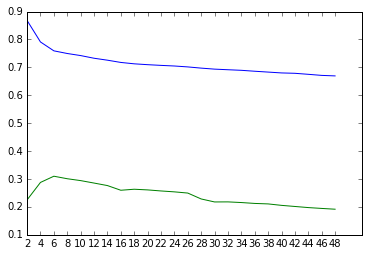

```python
plt.plot(np.mean(train_scores,axis=1))
plt.plot(np.mean(test_scores,axis=1))
plt.xticks(np.arange(24),n);
```

```python
from sklearn.model_selection import learning_curve

lcurve = learning_curve(KNeighborsRegressor(n_neighbors=6),X,y,cv=5)
samples,train,test = lcurve[0], lcurve[1],lcurve[2]
```

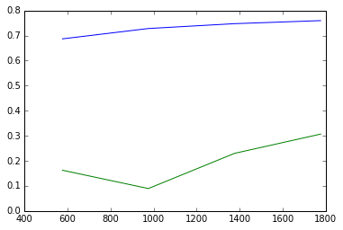

```python
plt.plot(samples[1:],np.mean(train,axis=1)[1:])
plt.plot(samples[1:],np.mean(test,axis=1)[1:])
```

[figure not shown]

El modelo aún está aprendiendo, sin embargo no tenemos como obtener datos adicionales.

**Como solucionar el overfitting y el underfitting?**

Viarianza Alta:

- Conseguir más ejemplos
- Reducir cantidad de features
- Aumentar coeficiente de regularización

Bias Alto:

- Más features
- Modelo más complejo

Mal resultado general:

- Probar otro algoritmo/familia de modelos, quizás las hipotesis del modelo no son cumplidad por tu dataset